# Домашнее задание №5

2023-06-01

# Задание 1

Загрузим данные, которые содержатся в файле protests.csv, и сохраним их в датафрейм pro.

```r
pro <- read.csv("protests.csv")
```

Выберем из датафрейма pro нужные нам столбцы и сохраним их в отдельный датафрейм d.

```r
d <- pro %>% dplyr::select(country, year, duration, part2, reaction, arrested, wounded)
```

Удалим строки с пропущенными значениями.

```r
d <- na.omit(d)
```

Агрегируем данные по странам и по годам.

```r
final <- d %>% group_by(country, year) %>%
               summarise(duration = sum(duration),
                         part2 = sum(part2),
                         reaction = sum(reaction),
                         arrested = sum(arrested),
                         wounded = sum(wounded))
final <- as.data.frame(final)
```

Сохраним в датафрейм m все переменные из final, кроме года и названия страны.

```r
m <- final %>% dplyr::select (duration, part2, reaction, arrested, wounded)
head(m)
```

```
##   duration  part2 reaction arrested wounded
## 1      360 629455    11919      136      14
## 2      260 360693    10845       63      31
## 3      287 715452    10834       70       7
## 4      272 246551     8395      104      31
## 5      187 539567     8944      112     122
## 6      443 460437    13108      123      84
```

# Задание 2

Реализуем на переменных из датафрейма m метод главных компонент с целью снизить размерность — перейти от выбранных 5 характеристик протестов к более общим характеристикам.

Так как показатели в датафрейме измерены в разных шкалах измерения необходимо центрировать и нормировать наши данные. Воспользуемся функцией `prcomp()`.

```r
pca <- prcomp(m, center = TRUE, scale = TRUE)
pca
```

```
## Standard deviations (1, .., p=5):
## [1] 1.9294196 0.7419670 0.6484467 0.4713142 0.2901804
##
## Rotation (n x k) = (5 x 5):
##                 PC1        PC2        PC3         PC4         PC5
## duration -0.4603603  0.4646695 -0.3527759  0.12505015  0.65731445
## part2    -0.4183310  0.1693309  0.8884696 -0.04182172  0.07210334
## reaction -0.4748435  0.4033850 -0.2408012 -0.01540626 -0.74403065
## arrested -0.4345467 -0.5955446 -0.0561144  0.67204217 -0.04130654
## wounded  -0.4458255 -0.4878692 -0.1582305 -0.72851587  0.08631902
```

Запишем выражение для второй главной компоненты`PC2`.
$$\text{PC}_2 = 0.4646695 \times \text{duration} + 0.1693309 \times
\text{part2} + 0.4033850 \times \text{reaction} - 0.5955446 \times
\text{arrested} - 0.4878692 \times \text{wounded}$$

# Задание 3

Проинтерпретируем две первые главные компоненты.

`PC1`: в данную главную компоненту все характеристики входят с примерно одинаковым отрицательным весом. То есть если исходные индексы отражали масшатбность протеста (чем выше значения, тем больше продолжительность, число участников, реакция на протест, число арестованных, число раненых), то наш индекс будет, наоборот, отражать “немасштабность”.

`PC2`: в данную главную компоненту с наибольшим отрицательным весом входят характеристики arrested и wounded, отражающие число раненых и число арестованных. То есть можно считать, что эта главная компонента отвечает за то, насколько протест был мирным (отражает степень ненасильственности протеста).

# Задание 4

Определим сколько главных компонент можно извлечь.

**Содержательно мы можем проинтерпретировать** первые *две главные компоненты*. Третья главная компонента включает с положительным весом только характеристику part2, которая отражает число участников, но это не очень информативно, так как данная харктеристика в целом уже учитывается в первой главной компоненте.

Согласно выдаче, только первая главная компонента имеет стандартное отклонение больше 1, а значит, и дисперсию выше 1. Следовательно, по **правилу Кайзера** мы должны извлечь только *одну главную компоненту*.

Посмотрим на **информативность** главных компонент:

```r
summary(pca)
```

```
## Importance of components:
##                           PC1    PC2    PC3     PC4     PC5
## Standard deviation     1.9294 0.7420 0.6484 0.47131 0.29018
## Proportion of Variance 0.7445 0.1101 0.0841 0.04443 0.01684
## Cumulative Proportion  0.7445 0.8546 0.9387 0.98316 1.00000
```

Первая главная компонента объясняет примерно 75% дисперсии исходных данных, можно считать, что этого достаточно (необходимо, чтобы ГК объясняли не менее 75-80% дисперсии исходных данных). Но лучше взять две ГК, так как вместе они объясняют 85,46% дисперсии исходных данных. Следовательно, согласно данному методу можно взять *одну или две главные компоненты*.

Посмотрим на **график каменистой осыпи**, который отображает убывание информативности главных компонент:

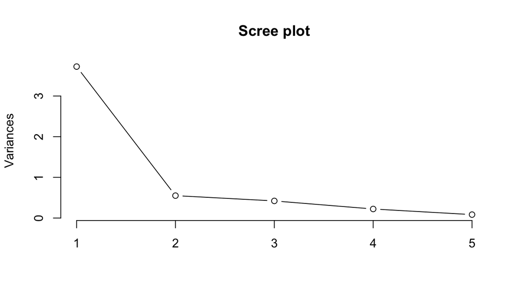

```r
plot(pca, type = "l", main = "Scree plot")
```

На графике каменистой осыпи виден излом для значения 2. Следовательно, согласно данному методу следует взять *две главных компоненты*.

Таким образом, полученное согласно данным методам число компонент совпадает с нашими ожиданиями и с содержательными соображениями. Можно извлечь одну или две главные компоненты, в зависимости от того, какая задача стоит в нашем исследовании.